# Class 04: Assignment

William Mechler

## Ice Breakers

We know folks do not necessarily like Ice Breakers but today you will put into a semi-permanent breakout room, so it is important you get to know your classmates as you’ll be seeing them regularly over the next month! These groups were chosen based on timezones, statistics experience and trying to diversify majors in a room. Please discuss and answer the following questions in regard to your group.

1. Who can speak the most languages? How many? What are they?

**N/A sadly we all only speak English.**

2. Whose majors is the furthest from statistics and what is it? (subjective question)

**Rill Howard with bio bioinformatics as a minor. As most of our majors were closely related to statistics.**

3. Which two group member’s birthdays are closest, and how many days apart are they?

**William Mechler August 4 and Victoria Castel June 31st, 35 days**

4. Who in your group has the most unusual talent, and what is it?

**Rylee Domonkos can use the nunchucks.**

## Espresso Brewing

Several brewing techniques are used to make espresso coffee. Among them, the most widespread are bar machines and single-dose capsules, designed in large numbers because of their commercial popularity. Using the same batch of water, operating settings and batch of coffee beans, espresso was made using three approaches coded as: 1 = Bar Machine, 2 = Hyper-Espresso Method (HIP), 3 = I-Espresso System (IT). The physic and chemical profile of the breweed espresso was summarized as a `foamInx` in the data.

Our goal for today is to perform a complete statistical analysis to determine if, and how, the different brewing methods result in different quality espresso.

#### Load packages needed; read in data

```r
library(tidyverse)
library(knitr)
library(ggfortify)
library(emmeans)

espresso <- read.csv("espresso_data.csv")
glimpse(espresso)
```

```
## Rows: 27
## Columns: 2
## $ foamIndx <dbl> 36.64, 39.65, 37.74, 35.96, 38.52, 21.02, 24.81, 34.18, 23...
## $ method   <int> 1, 1, 1, 1, 1, 1, 1, 1, 1, 2, 2, 2, 2, 2, 2, 2, 2, 2, 3, 3...
```

#### Question 1

Do a little data cleaning to create factor versions of the variables that require it.

```r
espresso <- espresso %>%
  mutate(method=factor(method, 1:3, labels=c("Bar Machine","Hyper-Espresso","I-Espresso System")))
glimpse(espresso)
```

```
## Rows: 27
## Columns: 2
## $ foamIndx <dbl> 36.64, 39.65, 37.74, 35.96, 38.52, 21.02, 24.81, 34.18, 23...
## $ method   <fct> Bar Machine, Bar Machine, Bar Machine, Bar Machine, Bar Ma...
```

#### Question 2

Discuss if this data is part of a **designed experiment** or an **observational study**. How do you know?

**Observational study due to the fact that it seems they are pulling their data from existing soucres.**

#### Question 3

Generate a meaningful (and properly labeled) plot to compare the distributions of the foam index between the three brewing methods. Comment on what you see, including comment on average and variation in foam index.

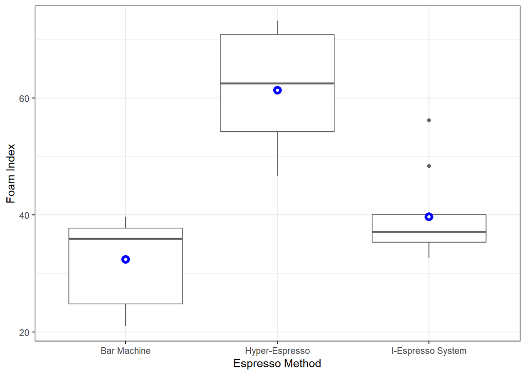

```r
ggplot(espresso, aes(x=method, y=foamIndx)) +
  geom_boxplot( col="gray40") +
  stat_summary(fun=mean, geom="point", shape=21, stroke=2, fill="white", color="blue")+
  labs(x="Espresso Method", y="Foam Index") +
  theme_bw()
```

**It appears that Hyper-Espresso has an higher foam index on average when compared to the other two brewing methods. Additional the I-Espresso method seems to have a lower variation when compared to the other two methods expect for it’s two out liners.**

#### Question 4

Run a one-way ANOVA to test to see if there is any difference in true mean foam index between the three brewing methods. You must cite the $F$-statistic value, both numerator and denominator degrees of freedom, the p-value, and the conclusion in problem context.

```r
espresso.anove <- aov(foamIndx ~ method, data=espresso)
summary(espresso.anove)
```

```
##             Df Sum Sq Mean Sq F value  Pr(>F)
## method       2   4065  2032.6   28.41 4.7e-07 ***
## Residuals   24   1717    71.5
## ---
## Signif. codes:  0 '***' 0.001 '**' 0.01 '*' 0.05 '.' 0.1 ' ' 1
```

**Our P value was 4.7e-07 with an F value of 28.41 and 2 degrees of freedom. With these values we see that there is a significant difference in out data set. Plus with our low P value we can trust our results and more ontp further testing if needed.**

#### Question 5

Check the model residuals to see if there are any suspected problems among the model assumptions.

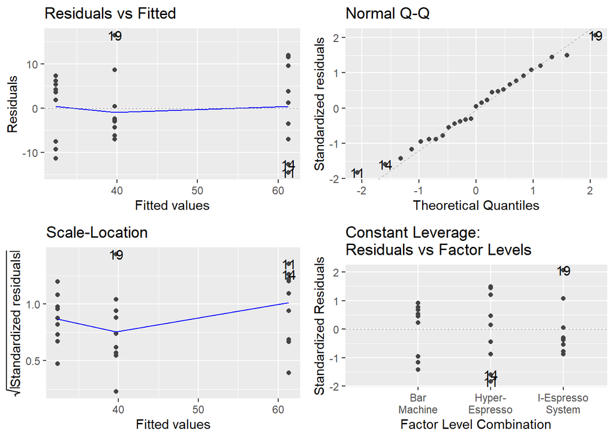

```r
autoplot(espresso.anove)
```

**We as a group see nothing wrong with how our residuals turned out.**

#### Question 6

Perform appropriate multiple comparisons (only if necessary!) and report the results in context. You must provide a defense of your choice to use Tukey or Dunnett (or neither!)

```r
espresso.mc <- emmeans(espresso.anove, "method")
contrast(espresso.mc, "pairwise")
```

```
##  contrast                               estimate   SE df t.ratio p.value
##  Bar Machine - (Hyper-Espresso)            -28.9 3.99 24 -7.248  <.0001
##  Bar Machine - (I-Espresso System)          -7.3 3.99 24 -1.831  0.1811
##  (Hyper-Espresso) - (I-Espresso System)     21.6 3.99 24  5.417  <.0001
##
## P value adjustment: tukey method for comparing a family of 3 estimates
```

**From the summary above we see when comparing Bar Machine to Hyper-Espresso and Hyper-Espresso to I-Espresso we have an p value below .05. With this we can see we have the evidence tot say there is statistically a difference for both comparisons.However the p value from Bar Machine to I-Espresso has a p value higher than .05 so we don’t have the evidence to say those two are statistically different. We used Tukey to compare our data because we did not have an control to test everything against. Because of this we use Tukey to compared each treatment against each other.**